# Network Anamoly Detection Final

## Fine Tuning GradientBoost Classifier

```
Fitting 3 folds for each of 30 candidates, totalling 90 fits
```

[output not shown]

[output not shown]

[output not shown]

[output not shown]

[output not shown]

[output not shown]

[output not shown]

[output not shown]

[output not shown]

[output not shown]

[output not shown]

[output not shown]

[output not shown]

[output not shown]

[output not shown]

[output not shown]

[output not shown]

[output not shown]

[output not shown]

[output not shown]

[output not shown]

[output not shown]

[output not shown]

[output not shown]

[output not shown]

[output not shown]

[output not shown]

[output not shown]

[output not shown]

[output not shown]

[output not shown]

[output not shown]

[output not shown]

[output not shown]

[output not shown]

[output not shown]

[output not shown]

[output not shown]

[output not shown]

[output not shown]

[output not shown]

[output not shown]

[output not shown]

[output not shown]

[output not shown]

[output not shown]

[output not shown]

[output not shown]

[output not shown]

[output not shown]

[output not shown]

[output not shown]

[output not shown]

[output not shown]

[output not shown]

[output not shown]

[output not shown]

[output not shown]

[output not shown]

[output not shown]

[output not shown]

[output not shown]

[output not shown]

[output not shown]

[output not shown]

[output not shown]

[output not shown]

[output not shown]

[output not shown]

[output not shown]

[output not shown]

[output not shown]

[output not shown]

[output not shown]

[output not shown]

[output not shown]

[output not shown]

[output not shown]

[output not shown]

[output not shown]

[output not shown]

[output not shown]

[output not shown]

[output not shown]

[output not shown]

[output not shown]

[output not shown]

[output not shown]

[output not shown]

[output not shown]

```
{'learning_rate': 0.1, 'max_depth': 8, 'n_estimators': 150}
[0.99606265 0.99627698 0.99651513 0.9966342  0.99807895 0.99834885
 0.99367325 0.99382407 0.99509419 0.99596739 0.9972375  0.99739627
 0.99578481 0.99625317 0.99652306 0.99669771 0.99811864 0.99830122
 0.99915061 0.99920618 0.99921412 0.9992935  0.9991268  0.99919824
 0.99914267 0.99921412 0.99920618 0.99920618 0.99920618 0.99920618]
0.99757196647959
F1 Score : 0.8398318211993804
Precision :  0.9719319811514034
Recall :  0.7393438790617938
Accuracy :  0.8394694819020582
```

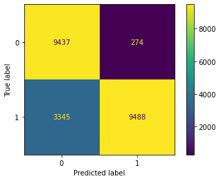

```
['GradBOOST_FineTuned_SC.sav']
```

```python
from sklearn.ensemble import GradientBoostingClassifier
from sklearn.model_selection import GridSearchCV


param_grid = {
    'n_estimators': [100,150],
    'learning_rate':[0.01,0.001,0.009,0.1,0.09],
    'max_depth':[7,8,9]
}
gb = GradientBoostingClassifier(random_state=500)

CV_gb = GridSearchCV(estimator=gb, param_grid=param_grid,\

                       cv=3,verbose=2)

CV_gb.fit(X_train, Y_train)

print(CV_gb.best_params_)
print(CV_gb.cv_results_['mean_test_score'])
print(sum(CV_gb.cv_results_['mean_test_score'])/ len(CV_gb.cv_results_['mean_test_score']))


Y_predict = CV_gb.predict(X_test)

#test the model on data X_test

f1,prec,recall, acc = eval_model(Y_test,Y_predict)
print("F1 Score :",f1)
print("Precision : ",prec)
print("Recall : ",recall)
print("Accuracy : ",acc)

#Plotting Confusion Matrix
plot_confusion_matrix(CV_gb, X_test, Y_test)
plt.show()
joblib.dump(CV_gb,"GradBOOST_FineTuned_SC.sav")
```

# BASIC FEATURES OF EACH NETWORK CONNECTION Column

##### 1 Duration: Length of time duration of the connection

##### 2 Protocol_type: Protocol used in the connection

##### 3 Service: Destination network service used

##### 4 Flag: Status of the connection – Normal or Error

##### 5 Src_bytes: Number of data bytes transferred from source to destination in single connection

##### 6 Dst_bytes: Number of data bytes transferred from destination to source in single connection

##### 7 Land: if source and destination IP addresses and port numbers are equal then, this variable takes value 1

else 0

##### 8 Wrong_fragment: Total number of wrong fragments in this connection

##### 9 Urgent: Number of urgent packets in this connection. Urgent packets are packets with the urgent bit

Activated

# CONTENT RELATED FEATURES OF EACH NETWORK Columns

##### 10 Hot: Number of „hot‟ indicators in the content such as: entering a system directory, creating programs

and executing programs

##### 11 Num_failed _logins: Count of failed login attempts

##### 12 Logged_in Login Status: 1 if successfully logged in; 0 otherwise

##### 13 Num_compromised: Number of ``compromised' ' conditions

##### 14 Root_shell: 1 if root shell is obtained; 0 otherwise

##### 15 Su_attempted: 1 if ``su root'' command attempted or used; 0 otherwise

##### 16 Num_root: Number of ``root'' accesses or number of operations performed as a root in the connection

##### 17 Num_file_creations: Number of file creation operations in the connection

##### 18 Num_shells: Number of shell prompts

##### 19 Num_access_files: Number of operations on access control files

##### 20 Num_outbound_cmds: Number of outbound commands in an ftp session

##### 21 Is_hot_login: 1 if the login belongs to the ``hot'' list i.e., root or admin; else 0

##### 22 Is_guest_login: 1 if the login is a ``guest'' login; 0 otherwise

# TIME RELATED TRAFFIC FEATURES OF EACH NETWORK CONNECTION VECTOR

##### 23 Count: Number of connections to the same destination host as the current connection in the past two

seconds

##### 24 Srv_count: Number of connections to the same service (port number) as the current connection in th e

past two seconds

##### 25 Serror_rate: The percentage of connections that have activated the flag (4) s0, s1, s2 or s3, among the

connections aggregated in count (23)

##### 26 Srv_serror_rate: The percentage of connections that have activated the flag (4) s0, s1, s2 or s3, among

the connections aggregated in srv_count (24)

##### 27 Rerror_rate: The percentage of connections that have activated the flag (4) REJ, among the connections

aggregated in count (23)

##### 28 Srv_rerror_rate: The percentage of connections that have activated the flag (4) REJ, among the

connections aggregated in srv_count (24)

##### 29 Same_srv_rate: The percentage of connections that were to the same service, among the connections

aggregated in count (23)

##### 30 Diff_srv_rate: The percentage of connections that were to different services, among the connections

aggregated in count (23)

##### 31 Srv_diff*host* rate: The percentage of connections that were to different destination machines among

the connections aggregated in srv_count (24)